# Byte-Size Brilliance: Small Steps to Big Automation

## Outline

- Quick intro
- Practical considerations for automating code
- Using flexible parameters for automation

# Introduction to Automation

## What is Automation?

- **Definition:** The process of making data analysis and reporting self-operating or self-regulating.

## Why Automation?

- **Streamlining**
- **Better decision making**
- **Scalability**
- **Cost-Effectiveness**
- **More fun in the future**
  - Prediction, trend identification, advanced analyses

# Automation Tools

## R

- In early stages, much of the automation will be data cleaning

```r
library(dplyr)
df |>
  mutate(
    across(
      matches("address"),
      ~ stringr::str_to_upper(.x)
    )
  )
```

## R

- As we build a suite of tools, there will be space for more analysis

```r
smooth_probability <- function(df, x, y){

   x <- enquo(x)
   y <- enquo(y)

  p <-
    ggplot(df, aes(x = {{x}}, y = {{y}})) +
      geom_point(size=2, alpha=0.4) +
      ## the confidence intervals are not correct for a binomial distribution
      ## the smooth function is too convenient not to use and I'm not sure how
      ## to calculate the binomial CI with the smooth function so we just turn it off
      stat_smooth(method="loess", size=1.5, se = FALSE) +
      scale_y_continuous(paste0("Probability of ", rlang::as_label(y)),
                         limits = c(0,1))
      xlab(paste0(rlang::as_label(x))) +
      theme_bw()

  p
}
```

## Other tools

- Python
  - Best for machine learning
- Tableau
  - Quick visualization
- SQL
  - Great for extracting data
- Batch files
  - Automating tasks within windows

# Optimizing Automation: Strategies and Solutions

## Effective Implementation

- If not well thought out, automation can be problematic
- But if we code defensively, we can protect against common issues
- Think about what can go wrong and make a plan to cover it

## Data Quality

- Incorporate data validation steps

Examples:

- Compare column names with expected
- Check for anomalies (e.g. missing dates, new diseases)
- Volume checks
- Files missing or moved

## Data Quality

```r
intake_colnames <- colnames(intake_data)
intake_colnames_old <- read.table("logs/intake-line-list-names.txt")
intake_colnames_old <- intake_colnames_old$V1
colnames_identical <- identical(intake_colnames, intake_colnames_old)

if (!colnames_identical) {
  send_slack_msg(
    paste(
      "Variables in the intake line list have been changed.",
      "Review the intake line list to make sure new patients are captured.",
      "Intake\\Line List.xlsx"
    )
  )
  ## depending on how critical integrity is, stop may be useful
  # stop()
}
```

## Data Quality

- This could be an alerting system or a manual review process

```r
tryCatch({
  source(
    file.path(
      "scripts",
      "02.get-geo-and-immunization-data.R"
    ),
    echo = TRUE,
    max.deparse.length = 1E4
  )},
  error =
    function(cond) {
      send_slack_msg(cond)
      send_slack_msg("Failed in 02.get-geo-and-immunization-data.R, stopping run")
      print(cond)
      stop()
    }
)
```

## Flexibility in Automation

- Design adaptable frameworks
  - Build in parameter variations
  - e.g. include sections of a report based on disease

````r
infections_in_data <- stringr::str_to_lower(all_infection_data$disease)
infections_in_data <- unique(infections_in_data)

if ("itis" %in% infections_in_data) {
  include_itis <- TRUE
}

\```{r, child = if(include_itis) '04_itis-indicators.Rmd'}
\```
````

## Flexibility in Automation

- F U N C T I O N S

```r
make_disease_plot <- function(infection) {

  plot_data <-
    df |>
      filter(stringr::str_to_lower(disease) %in% infection)

  max_y <- max(plot_data$incidence, na.rm = TRUE)
  max_y <- ceiling(max_y / 5) * 5

  disease_for_title <- stringr::str_to_title(infection)
  title <-
    paste0(
      "Number of cases of",
      infection,
      "in 2024"
    )

  ggplot(data = plot_data, aes(x = epi_week, y = incidence)) +
    geom_bar() +
    scale_y_continuous(
      "Number of Cases",
      limit = c(0, max_y)
    ) +
    ggtitle(title)
}

## totally real diseases
diseases_for_report <-
  c("itis", "luminoxia", "fractalgia", "echoflux", "spiralgroth")

disease_plots <- lapply(diseases_for_report, make_disease_plot)
```

## Simplifying Complexity and Maintanence

- Modular programming
  - Break big tasks down into smaller ones
  - Separate scripts

```markdown
00.batch-run.R
01.get-data.R
02.clean-data.R
03.analyze-data.R
04.pretty-plots.R
```

## Simplifying Complexity and Maintanence

- Version control

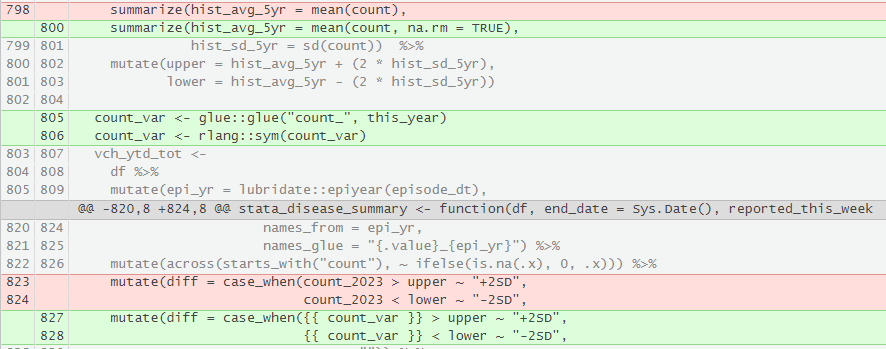

## Proactive Error Management

- Log runs
- Think about what’s likely to error
- Add alerts for failures
  - e.g. e-mails or slack messages

## Balanced Automation

- Avoid over-dependence
- Some steps will always need some oversight
  - e.g. free text fields should be reviewed

# Automation in Action

## Dates

There’s an outbreak of the itis!

```r
infection_data <-
  data.frame(
    diagnosis_date =
      as.Date(
        c("2024-03-04", "2024-03-04", "2024-03-08")
      ),
    case_id = c("A", "B", "C")
  )

infection_data
```

```
  diagnosis_date case_id
1     2024-03-04       A
2     2024-03-04       B
3     2024-03-08       C
```

```r
today <- as.Date("2024-03-15")
today
```

```
[1] "2024-03-15"
```

## Dates

How can we get cases for last week?

```r
cases_last_week <-
  infection_data |>
  dplyr::filter(diagnosis_date >= as.Date("2024-03-03")) |>
  dplyr::filter(diagnosis_date <= as.Date("2024-03-09"))

cases_last_week
```

```
  diagnosis_date case_id
1     2024-03-04       A
2     2024-03-04       B
3     2024-03-08       C
```

## Dates

A week passes by and now we’ve had new cases of itis.

```r
today <- as.Date("2024-03-22")

infection_data <-
  dplyr::bind_rows(
    infection_data,
    data.frame(
      diagnosis_date = as.Date("2024-03-13"),
      case_id = "D"
    )
  )

infection_data
```

```
  diagnosis_date case_id
1     2024-03-04       A
2     2024-03-04       B
3     2024-03-08       C
4     2024-03-13       D
```

## Dates

With a hard coded method, we would get the wrong data unless we manually make changes

```r
today
```

```
[1] "2024-03-22"
```

```r
cases_last_week <-
  infection_data |>
  dplyr::filter(diagnosis_date >= as.Date("2024-03-03")) |>
  dplyr::filter(diagnosis_date <= as.Date("2024-03-09"))

## wrong data!
cases_last_week
```

```
  diagnosis_date case_id
1     2024-03-04       A
2     2024-03-04       B
3     2024-03-08       C
```

## Dates

So we can make it flexible based on the todays date

```r
last_week_end <- today - (lubridate::wday(today) %% 7)
last_week_start <- last_week_end - 6

cases_last_week <-
  infection_data |>
  dplyr::filter(diagnosis_date >= last_week_start) |>
  dplyr::filter(diagnosis_date <= last_week_end)

cases_last_week
```

```
  diagnosis_date case_id
1     2024-03-13       D
```

## Dates

- We can also use these strategies for folders with varying dates

```r
this_year <- lubridate::year(today)

my_fake_path <-
  file.path(
    "some",
    "folder",
    "path",
    this_year,
    "data"
  )

my_fake_path
```

```
[1] "some/folder/path/2024/data"
```

## Dates

- This could be problematic at the beginning of the year

```r
today <- as.Date("2024-01-05")
this_year <- lubridate::year(today)

first_sunday <- function(.date) {

    first_day_of_month <- lubridate::floor_date(.date, unit = "months")
    week_dates <- seq(from = first_day_of_month, by = "days", length.out = 7)
    sunday <- week_dates[weekdays(week_dates) == "Sunday"]

    sunday[1]
}

if (lubridate::month(today) == 1 & today < first_sunday(today)) {
  this_year <- this_year - 1
}

my_fake_path <-
  file.path(
    "some",
    "folder",
    "path",
    this_year,
    "data"
  )

my_fake_path
```

```
[1] "some/folder/path/2023/data"
```

# Closing Thoughts

## Automation

- Everything takes practice
- Even if something isn’t going to be automated, use some of these concepts
  - modular
  - flexible objects
- Talk it out